# Task 3 - Bootstrapped confidence interval for proportions

Alex Ehrens

3/4/2021

### 1) Create vector of data reflecting UCSB survey results

```r
# start with vector of survey results (22 of 36 nonbinary/genderqueer students)
survey_vec <- c(rep(1, 22), rep(0, 14)) # set a value of 1 to be a "yes" response and value of 0 to be a "no" response

# make into data frame just for seeing data and responses side by side
survey_df <- data.frame(survey_vec) %>%
  mutate(response = case_when(
    survey_vec == 1 ~ "yes",
    survey_vec == 0 ~ "no"
  ))
```

### 2) Make function for calculating proportions from vectors of UCSB survey results

```r
# create function that calculates proportion of "yes" answers in any given sample
prop_function <- function(x, i){
  # since "yes" values are 1 and "no" values are 0, a sum of the vector will result in total number of "yes" votes across the entire sample
  # that sum can be divided by total number of individuals in sample to get proportion
  prop = sum(x[i]) / length(x[i])
}

# test function on survey data vector
fun_test <- prop_function(survey_vec)
fun_test
```

```
## [1] 0.6111111
```

### 3) Create bootstrap samples to find confidence interval

```r
# create 10,000 bootstrap samples from the survey vector
survey_boot_10k <- boot(survey_vec,
                        statistic = prop_function,
                        R = 10000)

# view results of proportions from all bootstrap samples
#survey_boot_10k$t
#survey_boot_10k

# find bootstrapped confidence interval
survey_boot_ci <- boot.ci(survey_boot_10k, conf = 0.95)
survey_boot_ci
```

```
## BOOTSTRAP CONFIDENCE INTERVAL CALCULATIONS
## Based on 10000 bootstrap replicates
##
## CALL :
## boot.ci(boot.out = survey_boot_10k, conf = 0.95)
##
## Intervals :
## Level      Normal              Basic
## 95%   ( 0.4481,  0.7691 )   ( 0.4444,  0.7778 )
##
## Level     Percentile            BCa
## 95%   ( 0.4444,  0.7778 )   ( 0.4167,  0.7222 )
## Calculations and Intervals on Original Scale
```

### 4) Plot a histogram of bootstrapped proportions

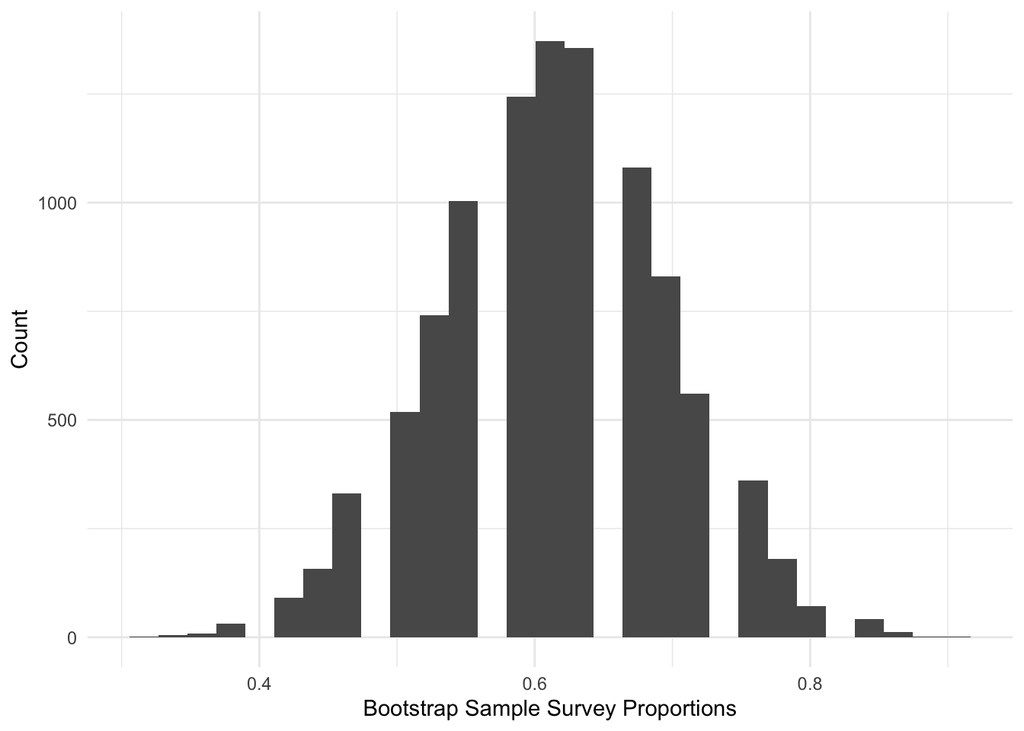

```r
# first convert bootstrapping results into data frame
survey_boot_10k_df <- data.frame(survey_props = survey_boot_10k$t)

# create histogram
ggplot(data = survey_boot_10k_df, aes(x = survey_props)) +
  geom_histogram() +
  labs(x = "Bootstrap Sample Survey Proportions",
       y = "Count") +
  theme_minimal()
```

#### Summary:

In a 2014 survey, a sample of 36 UCSB community members identifying as nonbinary/genderqueer were asked if they had personally experienced “exclusionary, offensive, hostile, or intimidating conduct”. Of that sample, 22 students (or a proportion of 0.61) had responded “yes”. This analysis created 10,000 bootstrap samples (resampling with replacement) using the original sample of 36 students as a “surrogate” population. Finding the proportion of students who would respond “yes” within each bootstrap sample provides a sampling distribution that can be used to find a bootstrapped confidence interval for the sample proportion of 0.61. This analysis found the bootstrapped 95% confidence interval to be from 0.45 to 0.77 (using a ‘normal’ confidence interval).

In other words, the proportion of nonbinary/genderqueer students at UCSB who experienced “exclusionary, offensive, hostile, or intimindating conduct” is 0.61 (n = 36), with a bootstrapped 95% confidence interval of [0.45, 0.77] (n = 10,000 bootstrap samples).

### Data Citation:

UCSB Campus Climate Project Final Report, 2014. Prepared by Rankin & Associates Consulting. Available at: http://campusclimate.ucop.edu/_common/files/pdf-climate/ucsb-full-report.pdf.

### END TASK 3